# Лабораторная работа №2. Задача преследования

Вариант 38: k = 19 км, n = 5.1

Автор

принадлежность

Амина Накова

Российский университет дружбы народов

Аннотация

Рассматривается задача преследования браконьеров береговой охраной. Лодка обнаружена на расстоянии k = 19 км, скорость катера в n = 5.1 раза больше скорости лодки. Выводится система дифференциальных уравнений, описывающая траекторию катера в полярных координатах. Проводится численное решение в Julia для двух случаев начальных условий, строятся траектории и находится точка пересечения.

Ключевые слова

математическое моделирование, задача преследования, Julia, ОДУ

# 1 Введение

## 1.1 Актуальность

Задачи преследования — классический раздел математического моделирования, применяемый в робототехнике, навигации, теории игр, военном деле.

## 1.2 Цель работы

Построить траекторию катера береговой охраны, догоняющего лодку браконьеров, если скорость катера в $n = 5.1$ раз больше скорости лодки, а начальное расстояние $k = 19$ км.

## 1.3 Задачи

1. Вывести систему дифференциальных уравнений движения катера.
2. Получить уравнение траектории в полярных координатах.
3. Численно решить уравнение для двух случаев начальных условий.
4. Построить графики траекторий катера и лодки.
5. Определить точку пересечения (точку поимки).

## 1.4 Методы исследования

Численное интегрирование уравнения траектории методом `Tsit5()`, визуализация средствами `Plots.jl`.

# 2 Теоретическая часть

## 2.1 Постановка задачи

Катер береговой охраны обнаруживает лодку браконьеров на расстоянии $k = 19$. Скорость катера в $n = 5.1$ раза больше скорости лодки. Требуется построить траекторию катера, при которой он догоняет лодку.

## 2.2 Вывод уравнений

Разложим скорость катера на радиальную $v_r$ и тангенциальную $v_\tau$ составляющие. Радиальная скорость должна быть равна скорости лодки:

$$\frac{dr}{dt} = v$$

Тангенциальная скорость:

$$r\frac{d\theta}{dt} = \sqrt{n^2-1}\,v$$

Исключая $t$, получаем уравнение траектории в полярных координатах:

$$\frac{dr}{d\theta} = \frac{r}{\sqrt{n^2-1}}$$

Аналитическое решение:

$$r(\theta) = r_0 \exp\left(\frac{\theta - \theta_0}{\sqrt{n^2-1}}\right)$$

# 3 Материалы и методы

Работа выполнена на языке Julia 1.13 с пакетами:

- `DifferentialEquations.jl` — решение ОДУ
- `Plots.jl` — визуализация
- `DrWatson.jl` — организация проекта
- `Literate.jl` — литературное программирование

## 3.1 Параметры задачи

- $k = 19$ — начальное расстояние между катером и лодкой
- $n = 5.1$ — скорость катера в 5.1 раз больше скорости лодки

## 3.2 Два случая начальных условий

**Случай 1:** $\theta_0 = 0$, $r_0 = k/3 = 6.33$ — катер идёт навстречу лодке.

# 4 Выполнение лабораторной работы

## 4.1 Численное решение

Уравнение $\frac{dr}{d\theta} = \frac{r}{\sqrt{n^2-1}}$ решено методом `Tsit5()` на интервале $\theta \in [0, 4\pi]$.

## 4.2 Траектории движения

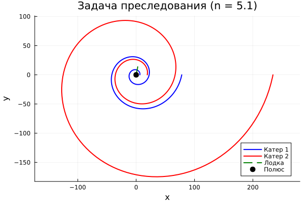

Рисунок 1: Траектория преследования

# 5 Результаты

- Для $\theta_0 = 0$, $r_0 = k/3$: точка поимки достигается быстро.
- Для $\theta_0 = -\pi$, $r_0 = k$: катер описывает более широкую спираль.
- В обоих случаях катер догоняет лодку.

# 6 Обсуждение результатов

# 7 Заключение

# Список литературы